# Revisão em grupo - Temperatura JP x CG

André Felipe / Aline Costa / Igor Dantas

```r
climas = read_csv(here::here("data/clima_cg_jp-semanal.csv"),
                  col_types = "cTdddddd")

glimpse(climas)
```

```
## Observations: 2,748
## Variables: 8
## $ cidade <chr> "Campina Grande", "Campina Grande", "Campina Grande", "Ca…
## $ semana <dttm> 1992-12-27, 1993-01-03, 1993-01-10, 1993-01-31, 1993-02-…
## $ tmedia <dbl> 26.13333, 26.11905, 25.76667, 25.74000, 26.31429, 26.2857…
## $ tmax   <dbl> 30.4, 32.4, 32.2, 32.0, 32.7, 32.7, 32.3, 32.3, 32.1, 31.…
## $ tmin   <dbl> 20.7, 19.3, 19.7, 19.9, 19.6, 20.0, 20.4, 21.2, 19.0, 19.…
## $ chuva  <dbl> 0.0, 0.0, 0.0, 0.4, 0.3, 0.0, 4.9, 0.0, 0.0, 6.1, 0.4, 1.…
## $ mes    <dbl> 12, 1, 1, 1, 2, 2, 2, 2, 10, 11, 11, 11, 11, 12, 12, 12, …
## $ ano    <dbl> 1992, 1993, 1993, 1993, 1993, 1993, 1993, 1993, 1993, 199…
```

### Qual foi o São João mais frio de CG que está nos nossos dados?

Ao observar no gráfico as médias de temperatura em Campina Grande no mês de Junho nos últimos anos (sabendo que o São João ocorre neste mês), É posséível afirmar que o São João mais frio foi o do ano de 2015 (com uma média de 22.62 graus). Pode-se observar que o ano de 2011 foi um ano em que o São João teve uma média de temperatura quase igual ao ano de 2015 (com uma média de 22.66 graus).

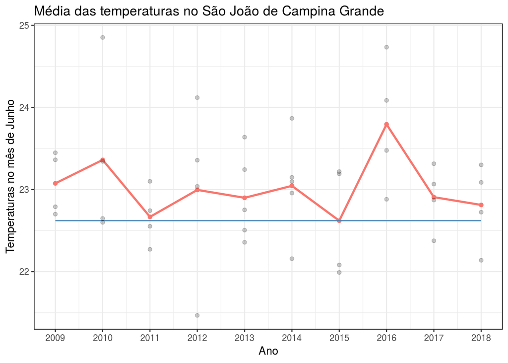

```r
climas2 <- climas %>%
    filter(ano >= 2009, mes == 6, cidade == "Campina Grande") %>%
    group_by(ano) %>%
    mutate(tmedia_sj = (sum(tmedia) / n())) %>%
    ungroup() %>%
    mutate(min_value = min(tmedia_sj)) %>%
    group_by(ano) %>%
    summarise(tmedia_sj = (sum(tmedia) / n()),
              min_value = min(min_value))


climas_ano <- climas %>%
    filter(ano >= 2009, mes == 6, cidade == "Campina Grande") %>%
    group_by(ano)


ggplot() +
    geom_line(data = climas2, aes(x = ano, y = tmedia_sj, color = "salmon"), size = 1) +
    geom_point(data = climas2, aes(x = ano, y = tmedia_sj, color = "salmon")) +
    geom_line(data = climas2, aes(x = ano, y = min_value), color='steelblue', size=0.5) +
    geom_point(data = climas_ano, aes(x = ano, y = tmedia), alpha = 2/10) +
    scale_x_continuous(breaks = seq(2009, 2018, 1)) +
    labs(
        title = "Média das temperaturas no São João de Campina Grande",
        x = "Ano",
        y = "Temperaturas no mês de Junho"
    ) +
    theme(legend.position = "none")
```

### No geral, onde chove mais?

Para responder a essa pergunta, vamos considerar a média de chuvas por mês a partir do ano de 2014 até 2018 (pontos e linhas coloridas), como também a média anual (linha em azul). Escolhemos esses anos pois esses tinham dados de todos os meses e para refletir uma realidade mais atual.

Vamos observar o gráfico de chuvas para a cidade de Campina Grande:

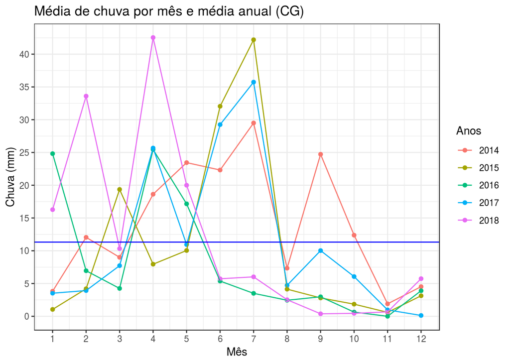

```r
cg_chuva <- climas %>%
            filter(cidade == "Campina Grande", ano > 2013 & ano < 2019) %>%
            select(chuva, semana, mes, ano, cidade) %>%
            group_by(mes, ano) %>%
            arrange(mes, ano) %>%
            summarise(media_chuva = sum(chuva) / n() )

 ggplot(data = cg_chuva, mapping = aes(x = mes , y = media_chuva, color = as.factor(ano) )) +
  geom_point() +
   geom_line() +
#  geom_col() +
#  geom_boxplot(coef = 1000, width = .4) +
#  geom_text(aes(label=mes + " " + ano),hjust=0, vjust=0) +
  geom_hline(aes(yintercept=mean(media_chuva)), show.legend = FALSE, color = "blue") +
  scale_x_continuous(breaks = seq(1,12,1)) +
  scale_y_continuous(breaks = seq(0,100,5)) +
#  theme(axis.text.x = element_text(angle = 90)) +
  labs(title = "Média de chuva por mês e média anual (CG)",
       x = "Mês",
       y = "Chuva (mm)",
       color = "Anos")
```

Agora vamos observar o gráfico de chuvas para a cidade de João Pessoa:

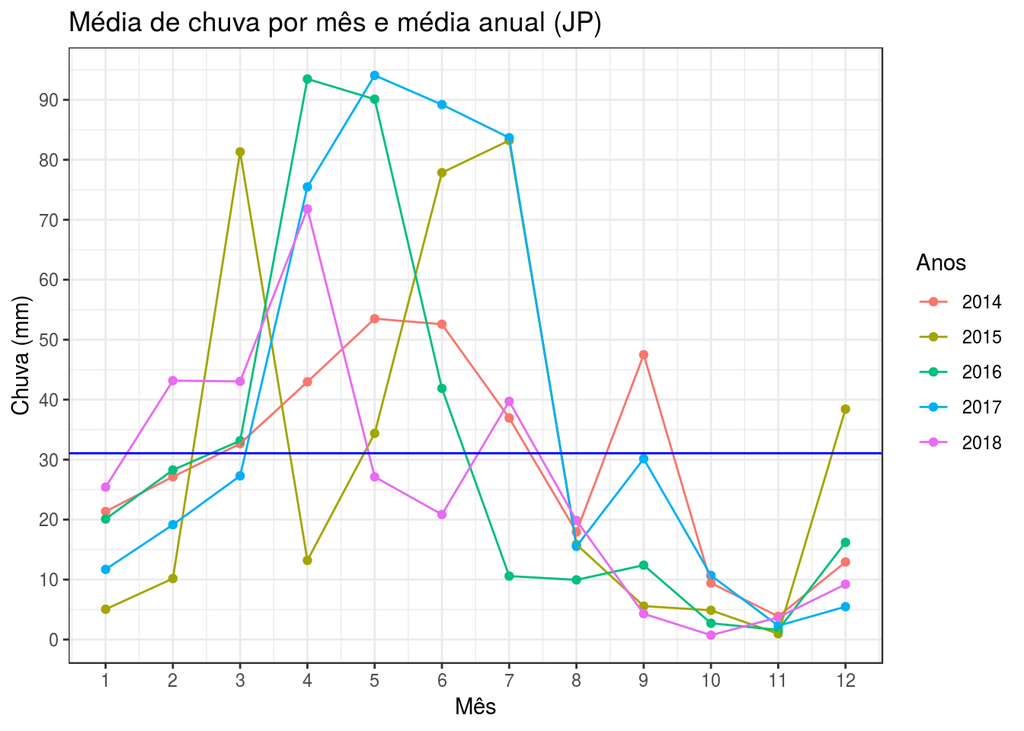

```r
jp_chuva <- climas %>%
            filter(cidade == "João Pessoa", ano > 2013 & ano < 2019) %>%
            select(chuva, semana, mes, ano, cidade) %>%
            group_by(mes, ano) %>%
            arrange(mes, ano) %>%
            summarise(media_chuva = sum(chuva) / n() )

 ggplot(data = jp_chuva, mapping = aes(x = mes , y = media_chuva, color = as.factor(ano) )) +
  geom_point() +
   geom_line() +
#  geom_col() +
#  geom_boxplot(coef = 1000, width = .4) +
#  geom_text(aes(label=mes + " " + ano),hjust=0, vjust=0) +
  geom_hline(aes(yintercept=mean(media_chuva)), show.legend = FALSE, color = "blue") +
  scale_x_continuous(breaks = seq(1,12,1)) +
  scale_y_continuous(breaks = seq(0,100,10)) +
#  theme(axis.text.x = element_text(angle = 90)) +
  labs(title = "Média de chuva por mês e média anual (JP)",
       x = "Mês",
       y = "Chuva (mm)",
       color = "Anos")
```

O mês que teve a maior média de chuvas em João Pessoa foi maio de 2017, onde choveu em torno de 95mm. Já a média anual durante os anos escolhidos em João Pessoa ficou em torno de 30mm.

Portanto, podemos perceber pelos gráficos que tanto a média de chuva mensal quanto a média de chuvas anual é maior em João Pessoa.

### Qual a distribuição das temperaturas no verão de João Pessoa?

Vamos analisar a distribuição das temperaturas médias na estação do verão na cidade de João Pessoa. Para melhor comparar a tendência, vamos restringir os dados aos últimos 5 anos.

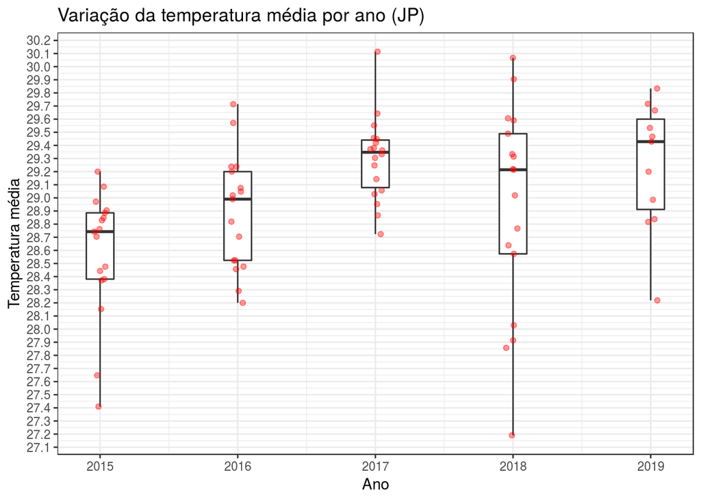

```r
# nova coluna para estação
climas = climas %>%  mutate(dia=lubridate::day(semana)) %>% mutate(estacao = if_else(mes>=4 & mes <=6, "outono", if_else(mes>=7 & mes <=9,  "inverno", if_else(mes>=9 & mes <=11,  "primavera", if_else(mes==12 | mes <=3,  "verao", "NA") ) ) ) )

temp_verao_jp_ultimos_5_anos <- climas %>%
  filter(cidade == "João Pessoa", ano > 2014, estacao == "verao") %>%
  group_by(ano);

 temp_verao_jp_ultimos_5_anos %>%
                            ggplot(aes(x = ano, y = tmedia, group = ano)) +
                                geom_boxplot(coef = 1000, width = .2) +
  # mostrar todos os boxplots em um só gráfico
  # facet_wrap(~ano)

  # mostrar pontos
  geom_jitter(width = 0.05,
                alpha = 0.4,
                color = "red") +
  # nomes formatados nos eixos
  labs(
        x = 'Ano',
        y = "Temperatura média",
        title = "Variação da temperatura média por ano (JP)"
    ) +
  # visualizar melhor as temperaturas
  scale_y_continuous(breaks = seq(15,40,0.1))
```